# MATH9102-CAPhase2-Task2+3-Example

Author

Deirdre Lawless

# 1. Introduction

This analysis investigates whether key psychological factors, in particular life satisfaction and positive affect, predict the likelihood of an individual being in a relationship controlling for socially desirable responding. A secondary research objective is to evaluate whether this predictive relationship varies across categories of educational attainment. These aims are explored using binary logistic regression.

Two models were fitted:

- Baseline Model: Life satisfaction and positive affect predicting relationship status controlling for social desirability.
- Comparison Model: Adds education level to examine whether predictors operate differently across educational groups.

# 2. Methods

Data were obtained from a psychological well-being survey containing validated scales measuring life satisfaction (Diener et al., 1985), positive affect (Watson et al., 1988), and social desirability (Crowne & Marlowe, 1960). Demographic data—including marital status and education level—were also collected. Relationship status was recoded into a binary variable (0 = not in a relationship; 1 = in a relationship).

Continuous variables were screened for normality using heuristic criteria from Curran, West, and Finch (1996) and Field (2025), whereby standardized skewness and kurtosis values within ±2 and 99.7% of absolute scores within +/- 3.29 indicate approximate normality. Although logistic regression does not assume normality of predictors, these checks guided the selection of appropriate exploratory tests.

Missing data were inspected following Tabachnick and Fidell (2016), and as the proportion and pattern of missingness did not raise concern, listwise deletion was applied.

The analytic workflow was as follows:

- Data preparation: recoding, screening for missingness, and descriptive analysis.
- Exploration: t-tests comparing psychological factors across relationship groups and chi-square tests assessing associations with education level.
- Model fitting: logistic regression using the logit link function.
- Model evaluation: likelihood-ratio tests, pseudo-R² estimates, and classification performance.
- Diagnostics: Hosmer–Lemeshow test, variance inflation factors (VIF), and influence statistics (Cook’s distance, leverage, standardized residuals).
- Interpretation: odds ratios, predicted probabilities, AUC, and confusion matrices.

A significance threshold of p < .05 was applied throughout, and model performance was evaluated using likelihood-ratio tests, pseudo-R² measures, area under the ROC curve (AUC), and classification accuracy. All analyses adhered to best-practice guidance for regression modelling, including assumption checking and inspection of influential observations.

# 3. Data Preparation and Exploration Results

Marital status was recoded from the original eight categories into a binary categorical variable 0 not in a relationship, 1 in a relationship.

Education levels were unevenly distributed, with some very small categories. “Primary education” was removed due to insufficient sample size.

Independent-samples t-tests examined differences between respondents in a relationship and those not in a relationship (see Appendix 1):

- Life satisfaction was significantly higher among respondents in a relationship, t(427) = −4.22, p < .001, η² = .04.
- Positive affect did not differ significantly between groups, t(427) = −1.07, p = .28.
- Social desirability was slightly but significantly higher among those in relationships, t(427) = −2.77, p = .006, η² = .02.

A chi-square test demonstrated a small association between relationship status and educational attainment, χ²(4, N = 429) = 20.17, p < .001, φ = .22.

Together, these results justify inclusion of psychological and educational variables in the regression models.

# 4. Baseline Model : Pyschological Predictors Only

## 4.1 Model Fit

A binary logistic regression model was built to examine whether life satisfaction and positive affect could be considered to predict relationship status controlling for socially desirable responding. The overall model was statistically significant, χ²(3, N = 429) = 23.92, p < .001, indicating the predictors reliably distinguished between respondents in and out of relationships. Pseudo-R² values indicated modest explanatory power:

- Cox–Snell R² = .054
- Nagelkerke R² = .075

-Tjur’s R² = .055

Together, these values indicate that the predictors explained between 5.4–7.5% of the variance in relationship status.

The odds ratios associated with each predictor are shown below. Positive affect was not a significant predictor, p = .365, indicating no reliable association with relationship status after controlling for the other variables.

| Predictor | B | p | OR | Interpretation |
| --- | --- | --- | --- | --- |
| Life satisfaction | 0.0676 | < .001 | **1.07** | Higher life satisfaction increases odds of being in a relationship. |
| Positive affect | –0.0146 | .365 | 0.99 | No meaningful contribution after other variables included. |
| Social desirability | 0.1306 | .014 | **1.14** | Higher socially desirable responding increases odds of reporting being in a relationship. |

**Table 1: Odds Ratios for Baseline Model**

The baseline model shows that life satisfaction and social desirability are significant independent predictors of relationship status. Individuals with higher life satisfaction and higher socially desirable responding are more likely to report being in a relationship. However, prediction accuracy is limited, and the model struggles particularly with identifying individuals who are not in a relationship. Overall, the model provides statistically significant but practically modest predictive usefulness.

## 4.2 Model Assumptions

The Hosmer–Lemeshow test was used to evaluate the agreement between observed and predicted probabilities. The test was not statistically significant, χ²(8) = 3.53, p = .897, indicating no evidence of poor fit. This suggests that the model adequately describes the data and that predicted values closely align with observed outcomes.

Multicollinearity was assessed using Variance Inflation Factors (VIFs). All predictors had VIF values between 1.01 and 1.23 (tolerances > .80), well below conventional thresholds for concern. These results indicate that the predictors do not exhibit problematic overlap and that collinearity is unlikely to distort coefficient estimates or model interpretation.

Residuals were examined to evaluate overall model adequacy. Pearson residuals were primarily within ±2, and deviance residuals were small and symmetrically distributed, indicating no major violations of model assumptions. There was no evidence of systematic patterns or heterogeneity.

Across all diagnostic checks, baseline model met the assumptions of logistic regression. The model showed acceptable fit, no multicollinearity, no influential cases, and no residual anomalies. These results indicate that baseline modelis appropriate for interpretation, although its overall predictive performance remains modest (see Appendix 2 for plots and test output).

## 4.3. Summary

The baseline logistic regression model examined whether life satisfaction, positive affect, and social desirability predicted the likelihood of being in a relationship. The model was statistically significant overall and explained a modest proportion of variance (Nagelkerke R² = .075). Life satisfaction and social desirability emerged as significant positive predictors, indicating that higher scores on these psychological factors increased the odds of being in a relationship, whereas positive affect showed no meaningful contribution. Model predictions demonstrated limited practical accuracy: although sensitivity was high, specificity was extremely low, and the ROC curve indicated only modest discrimination (AUC ≈ .64).

Assumption checks showed no evidence of poor fit, multicollinearity, or influential outliers, suggesting the model was statistically appropriate. Overall, the baseline model identifies two reliable psychological predictors but provides only modest usefulness for predicting relationship status.

# 5. Comparison Model: Including Educational Level

This model extended the baseline model by adding education level as a categorical predictor to test whether demographic background improves prediction. No interaction terms were included here, although education was hypothesised to create differential effects on the prediction.

## 5.1 Model Fit

Odds ratios indicated that both pyschnological predictors meaningfully influenced the likelihood of being in a relationship:

- Life satisfaction remained a significant positive predictor (OR = 1.08), demonstrating that each one-unit increase in life satisfaction was associated with an 8% increase in the odds of being in a relationship.
- Social desirability also showed a small but significant positive effect (OR = 1.12), while positive affect did not contribute significantly to the model (OR ≈ 0.99).

Education level showed differential associations. Compared to respondents who completed high school (the reference category):

- respondents with postgraduate education were more than twice as likely to be in a relationship (OR = 2.12)
- resppndents with some additional training were 90% more likely (OR = 1.90)
- respondents with some secondary education showed the strongest effects (OR = 7.20), indicating substantially higher odds of being in a relationship.

Predicted probabilities reflected these patterns, ranging from approximately .57 for high-school graduates to .91 for those with some secondary education.

Collectively, these results show that both psychological factors and educational attainment meaningfully shape relationship likelihood, with the latter introducing notable variability in predicted outcomes.

This model demonstrated modest predictive performance. The confusion matrix showed that the model correctly classified 41 non-relationship cases and 261 relationship cases, corresponding to an overall accuracy of approximately 70%. Sensitivity (the ability to correctly identify individuals in a relationship) was high, whereas specificity (correct identification of those not in a relationship) remained low, indicating a bias toward predicting the majority class.

The ROC curve yielded an AUC of .70, reflecting acceptable discrimination. This suggests that while the model is far from perfect, it performs meaningfully better than chance in distinguishing between individuals who are and are not in a relationship. Taken together, the classification results and AUC indicate that this model provides reasonable predictive capability, with enhanced performance relative to the baseline model, particularly when educational attainment is included as a predictor.

## 5.2 Assumptions Checks

Assumptions of logistic regression were evaluated to ensure that this model was appropriately specified (see Appendix 3 for plots and test output). The Hosmer–Lemeshow goodness-of-fit test, was non-significant, χ²(8) = 2.49, p = .96, indicating that the predicted probabilities aligned well with the observed data. This result suggests that the model fits the data adequately.

Multicollinearity was examined using Generalised Variance Inflation Factors (GVIFs). All GVIF-adjusted values were close to 1 (tlifesat = 1.13; tposaff = 1.11; tmarlow = 1.01; educ = 1.01), demonstrating that there was no problematic multicollinearity among the predictors.

Finally, residual deviance and degrees of freedom suggested no evidence of overdispersion, and the pattern of deviance residuals did not indicate model misspecification. Overall, the diagnostic checks showed that the model met the core assumptions of logistic regression, and the model can therefore be considered appropriate and statistically reliable for interpretation.

## 5.3 Summary

This model shows that educational attainment improves prediction over psychological factors alone. Several education levels significantly increase the odds of being in a relationship, particularly “Some secondary” and “Postgraduate”. The model’s predictive ability is however modest.

# 6. Model Comparison

A comparison of the baseline model and second model was conducted to determine whether the inclusion of education level improved prediction of relationship status. The second model demonstrated a lower AIC (AIC = 514.76) compared with baseline model (AIC = 530.21), indicating a modest improvement in model fit.

The Likelihood Ratio Test also supported the enhanced fit of the comparison model: the second model showed a significantly better log-likelihood than the intercept-only model, χ²(7) = 47.37, p < .001, compared with the baseline model’s χ²(3) = 23.92, p < .001. This represents a meaningful increase in explained variance. Similarly, pseudo-R² values increased from Nagelkerke R² = .075 in the baseline to .145 in second model, indicating a substantial improvement in the model’s explanatory capability.

Changes in predictor significance revealed that the core psychological predictors, life satisfaction and social desirability, remained significant or near-significant across both models, while positive affect continued to show no predictive value. The addition of education introduced several new significant predictors, with higher educational attainment associated with increased odds of being in a relationship in some categories. This demonstrates that education captures additional relevant variance not accounted for by psychological predictors alone.

Overall, the second model provides a clearer, more robust, and better-performing account of relationship status than the baseline model. The improvements in AIC, pseudo-R², classification metrics, and AUC, combined with stable diagnostics, indicate that the updated model is superior to the baseline model.

# 7. Summary

This analysis examined the extent to which life satisfaction, positive affect, and social desirability predict the likelihood of being in a relationship, and whether education level adds explanatory value. Two logistic regression models were fitted: a baseline model including only psychological predictors and a comparison model incorporating education. The baseline model showed modest predictive ability, with life satisfaction and social desirability emerging as significant predictors. Adding education improved overall model fit, increased explained variance, and enhanced classification accuracy and discrimination. Assumption checks indicated that both models were well specified, with the second model showing particularly strong calibration and no diagnostic concerns. Overall, the comparison model provided a more comprehensive and accurate understanding of factors associated with relationship status.

# References

# Appendix 1 - Descriptives, Plots and Exploratory Tests

## Continuous Data

```
$skewness_rounded
skew (g1)
     2.77

$skew_judgment
     skew (g1)
"unacceptable"

$kurtosis_rounded
Excess Kur (g2)
           1.92

$kurtosis_judgment
Excess Kur (g2)
   "acceptable"

$perc_within_3_29
[1] 0

$normality_judgment
[1] "can be considered normal"

$central_tendency
[1] "M: 22.37 SD: 6.75"
```

```
$skewness_rounded
skew (g1)
     4.59

$skew_judgment
     skew (g1)
"unacceptable"

$kurtosis_rounded
Excess Kur (g2)
            1.3

$kurtosis_judgment
Excess Kur (g2)
   "acceptable"

$perc_within_3_29
[1] 0

$normality_judgment
[1] "can be considered normal"

$central_tendency
[1] "M: 33.7 SD: 7.25"
```

```
$skewness_rounded
skew (g1)
      0.7

$skew_judgment
   skew (g1)
"acceptable"

$kurtosis_rounded
Excess Kur (g2)
            2.6

$kurtosis_judgment
Excess Kur (g2)
 "unacceptable"

$perc_within_3_29
[1] 0

$normality_judgment
[1] "can be considered normal"

$central_tendency
[1] "M: 5.29 SD: 2.04"
```

```
     nbr.val     nbr.null       nbr.na          min          max        range
 429.0000000    0.0000000    0.0000000    5.0000000   35.0000000   30.0000000
         sum       median         mean      SE.mean CI.mean.0.95          var
9597.0000000   23.0000000   22.3706294    0.3260378    0.6408344   45.6029671
     std.dev     coef.var
   6.7529969    0.3018689
```

```
     nbr.val     nbr.null       nbr.na          min          max        range
4.290000e+02 0.000000e+00 0.000000e+00 1.100000e+01 4.900000e+01 3.800000e+01
         sum       median         mean      SE.mean CI.mean.0.95          var
1.445700e+04 3.400000e+01 3.369930e+01 3.502313e-01 6.883874e-01 5.262199e+01
     std.dev     coef.var
7.254101e+00 2.152597e-01
```

```
     nbr.val     nbr.null       nbr.na          min          max        range
4.290000e+02 1.000000e+00 0.000000e+00 0.000000e+00 1.000000e+01 1.000000e+01
         sum       median         mean      SE.mean CI.mean.0.95          var
2.270000e+03 5.000000e+00 5.291375e+00 9.825443e-02 1.931213e-01 4.141538e+00
     std.dev     coef.var
2.035077e+00 3.846026e-01
```

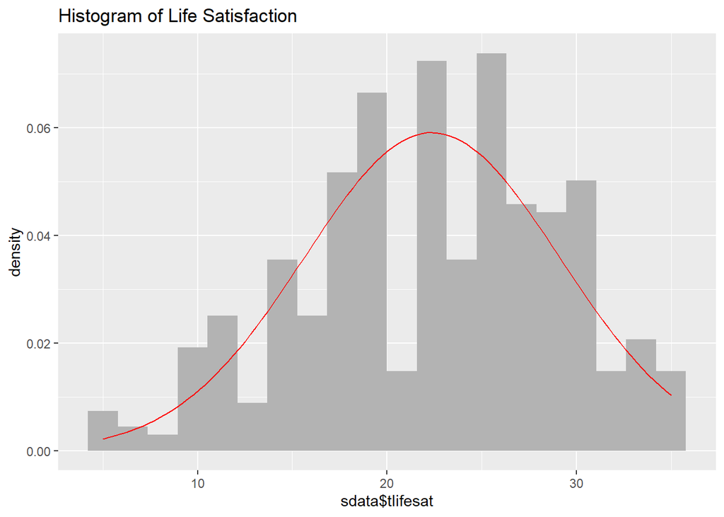

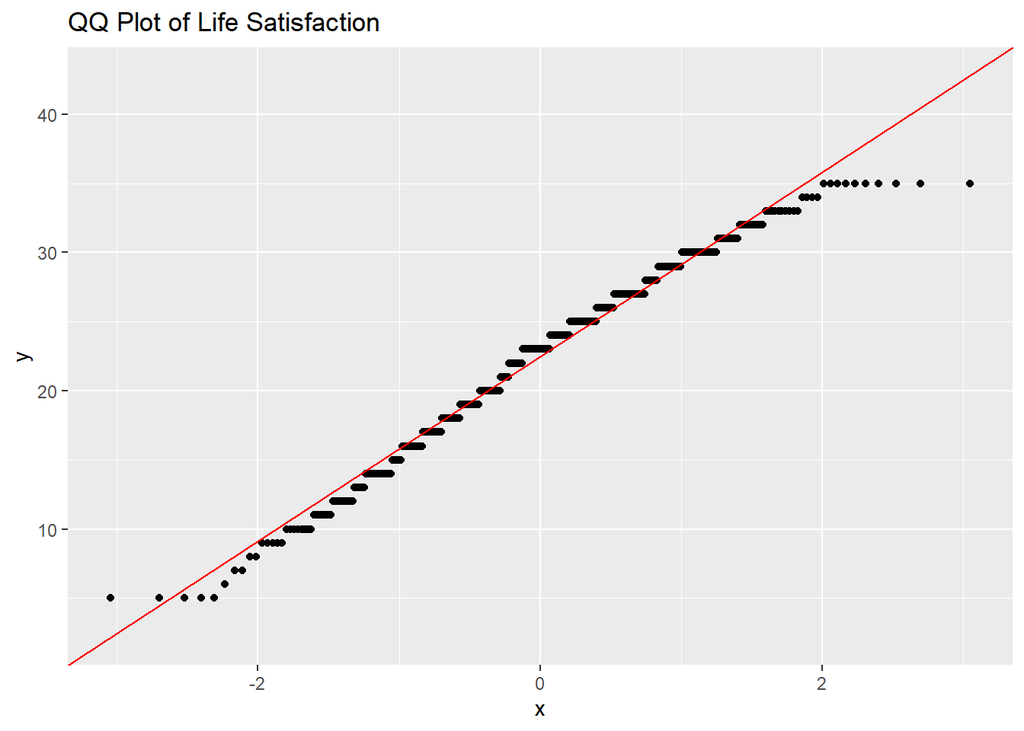

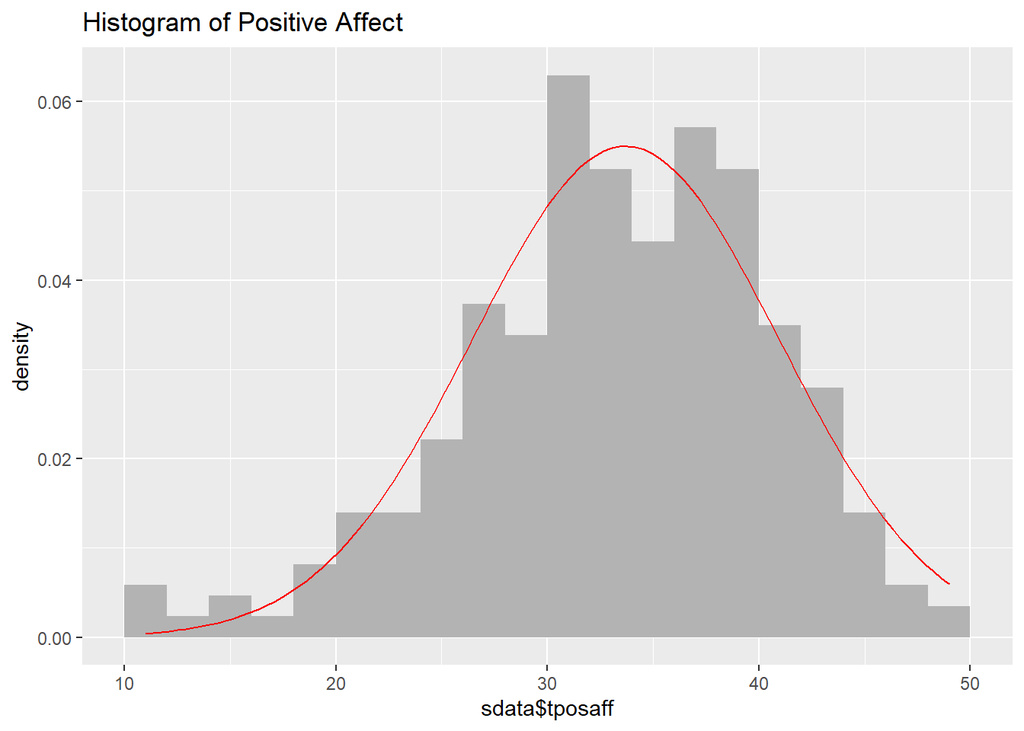

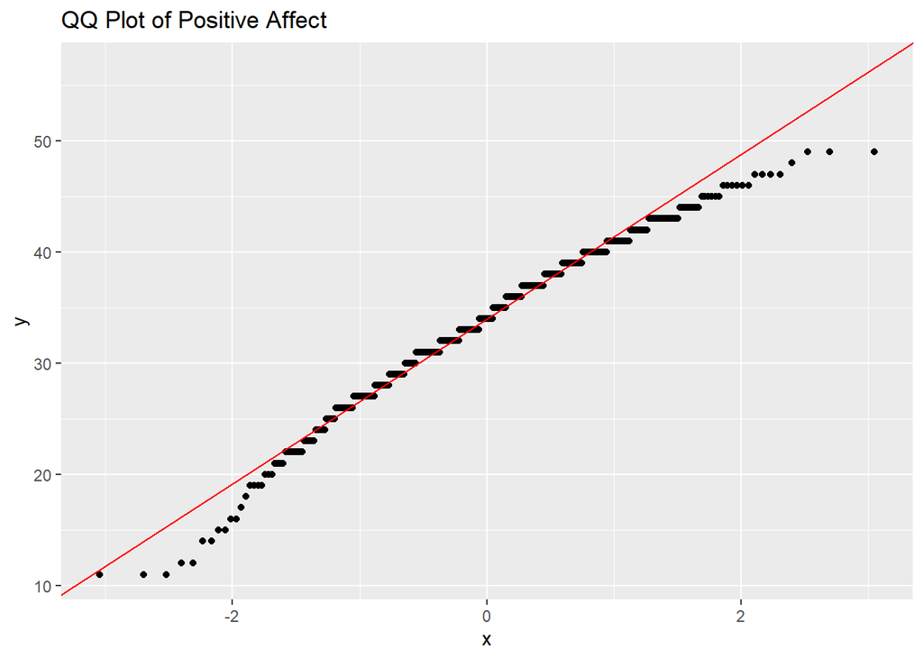

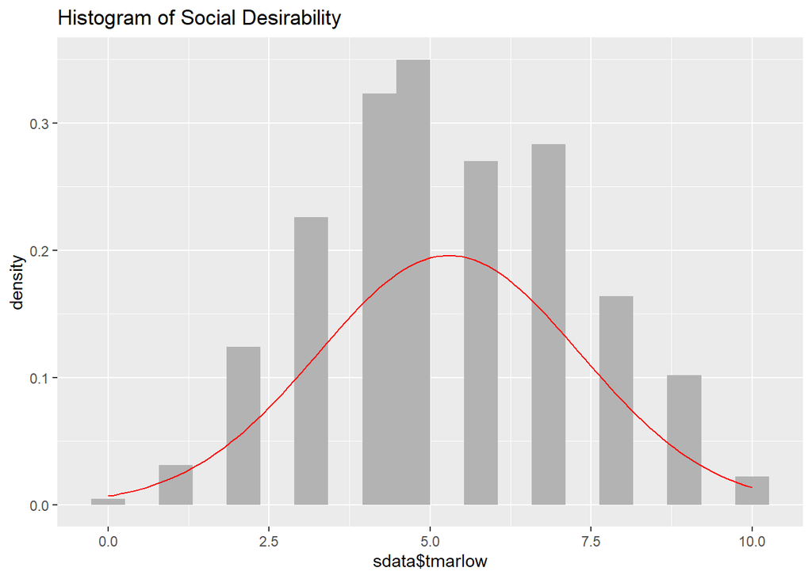

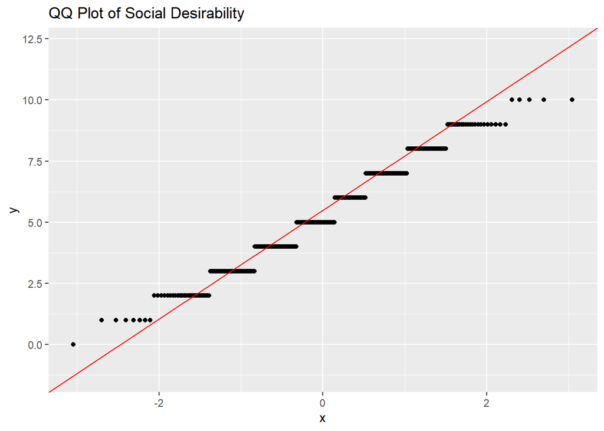

## Categorical Data

```
  0   1
143 286
```

```
    COMPLETED HIGHSCHOOL  COMPLETED UNDERGRADUATE   POSTGRADUATE COMPLETED
                      84                      123                       56
SOME ADDITIONAL TRAINING           SOME SECONDARY
                     115                       51
```

## Exploratory Tests

```
    item group1 vars   n     mean       sd median  trimmed   mad min max range
X11    1      0    1 143 20.46154 6.895364     20 20.54783 7.413   5  35    30
X12    2      1    1 286 23.32517 6.484735     24 23.63043 7.413   5  35    30
          skew   kurtosis        se
X11 -0.1235511 -0.5524580 0.5766193
X12 -0.4106422 -0.3800972 0.3834504
```

```
    item group1 vars   n     mean       sd median  trimmed   mad min max range
X11    1      0    1 143 33.16783 7.419033     33 33.43478 7.413  11  49    38
X12    2      1    1 286 33.96503 7.168560     34 34.41739 7.413  11  49    38
          skew  kurtosis        se
X11 -0.4296918 0.1220984 0.6204107
X12 -0.5919680 0.3520912 0.4238858
```

```
    item group1 vars   n     mean       sd median  trimmed    mad min max range
X11    1      0    1 143 4.909091 1.971305      5 4.878261 1.4826   1  10     9
X12    2      1    1 286 5.482517 2.042885      5 5.469565 2.9652   0  10    10
          skew   kurtosis        se
X11 0.15299775 -0.5222983 0.1648488
X12 0.03614453 -0.6903836 0.1207983
```

```
$descriptives
    item group1 vars   n     mean       sd median  trimmed   mad min max range
X11    1      0    1 143 20.46154 6.895364     20 20.54783 7.413   5  35    30
X12    2      1    1 286 23.32517 6.484735     24 23.63043 7.413   5  35    30
          skew   kurtosis        se
X11 -0.1235511 -0.5524580 0.5766193
X12 -0.4106422 -0.3800972 0.3834504

$t
       t
-4.22097

$tdf
 df
427

$tpvalue
[1] 2.973696e-05

$cohen_d
d     |         95% CI
----------------------
-0.41 | [-0.60, -0.22]

$eta_squared
   t
0.04
```

```
$descriptives
    item group1 vars   n     mean       sd median  trimmed   mad min max range
X11    1      0    1 143 33.16783 7.419033     33 33.43478 7.413  11  49    38
X12    2      1    1 286 33.96503 7.168560     34 34.41739 7.413  11  49    38
          skew  kurtosis        se
X11 -0.4296918 0.1220984 0.6204107
X12 -0.5919680 0.3520912 0.4238858

$t
       t
-1.07321

$tdf
 df
427

$tpvalue
[1] 0.2837832

$cohen_d
d     |        95% CI
---------------------
-0.10 | [-0.29, 0.09]

$eta_squared
    t
0.003
```

```
$descriptives
    item group1 vars   n     mean       sd median  trimmed    mad min max range
X11    1      0    1 143 4.909091 1.971305      5 4.878261 1.4826   1  10     9
X12    2      1    1 286 5.482517 2.042885      5 5.469565 2.9652   0  10    10
          skew   kurtosis        se
X11 0.15299775 -0.5222983 0.1648488
X12 0.03614453 -0.6903836 0.1207983

$t
        t
-2.772592

$tdf
 df
427

$tpvalue
[1] 0.005804592

$cohen_d
d     |         95% CI
----------------------
-0.27 | [-0.46, -0.08]

$eta_squared
    t
0.018
```

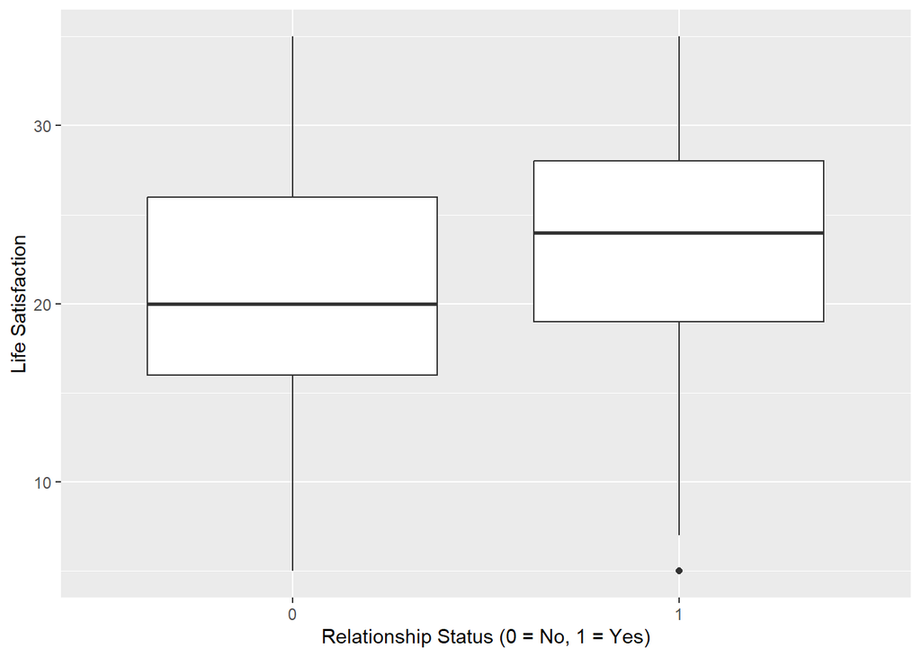

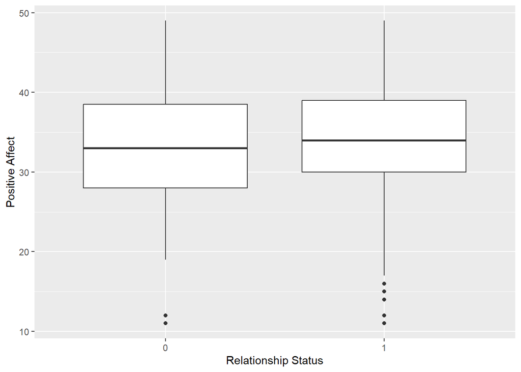

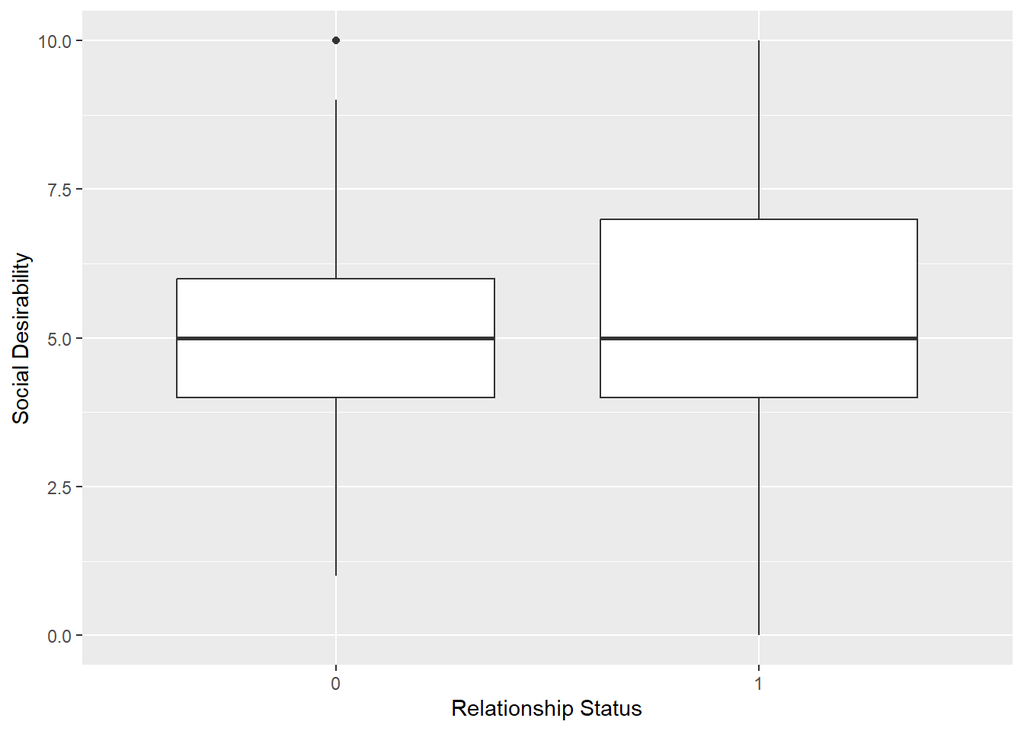

```
    Pearson's Chi-squared test

data:  mytable
X-squared = 20.171, df = 4, p-value = 0.000462
```

```
[1] 0.2168384
```

# Appendix 2 - Baseline Model

## Model Fit

```
Call:
glm(formula = mstatus ~ tlifesat + tposaff + tmarlow, family = binomial(link = "logit"),
    data = sdata)

Coefficients:
            Estimate Std. Error z value Pr(>|z|)
(Intercept) -0.97520    0.56409  -1.729 0.083843 .
tlifesat     0.06757    0.01746   3.870 0.000109 ***
tposaff     -0.01460    0.01610  -0.906 0.364709
tmarlow      0.13057    0.05313   2.457 0.013992 *
---
Signif. codes:  0 '***' 0.001 '**' 0.01 '*' 0.05 '.' 0.1 ' ' 1

(Dispersion parameter for binomial family taken to be 1)

    Null deviance: 546.13  on 428  degrees of freedom
Residual deviance: 522.21  on 425  degrees of freedom
AIC: 530.21

Number of Fisher Scoring iterations: 4
```

```
Likelihood ratio test

Model 1: mstatus ~ tlifesat + tposaff + tmarlow
Model 2: mstatus ~ 1
  #Df  LogLik Df  Chisq Pr(>Chisq)
1   4 -261.11
2   1 -273.06 -3 23.916  2.601e-05 ***
---
Signif. codes:  0 '***' 0.001 '**' 0.01 '*' 0.05 '.' 0.1 ' ' 1
```

```
  CoxSnell
0.05422215
```

```
Nagelkerke
 0.0753067
```

```
# R2 for Logistic Regression
  Tjur's R2: 0.055
```

## Odds Ratios

```
Parameter   | Odds Ratio |   SE |       95% CI |     z |      p
---------------------------------------------------------------
(Intercept) |       0.38 | 0.21 | [0.12, 1.13] | -1.73 | 0.084
tlifesat    |       1.07 | 0.02 | [1.03, 1.11] |  3.87 | < .001
tposaff     |       0.99 | 0.02 | [0.95, 1.02] | -0.91 | 0.365
tmarlow     |       1.14 | 0.06 | [1.03, 1.27] |  2.46 | 0.014
```

## Predicted Probabilities

```
 tlifesat  prob     SE  df asymp.LCL asymp.UCL
     22.4 0.676 0.0234 Inf     0.629      0.72

Confidence level used: 0.95
Intervals are back-transformed from the logit scale
```

```
 tposaff  prob     SE  df asymp.LCL asymp.UCL
    33.7 0.676 0.0234 Inf     0.629      0.72

Confidence level used: 0.95
Intervals are back-transformed from the logit scale
```

```
 tmarlow  prob     SE  df asymp.LCL asymp.UCL
    5.29 0.676 0.0234 Inf     0.629      0.72

Confidence level used: 0.95
Intervals are back-transformed from the logit scale
```

```
 tlifesat tposaff tmarlow  prob     SE  df asymp.LCL asymp.UCL
     22.4    33.7    5.29 0.676 0.0234 Inf     0.629      0.72

Confidence level used: 0.95
Intervals are back-transformed from the logit scale
```

## ROC Curve

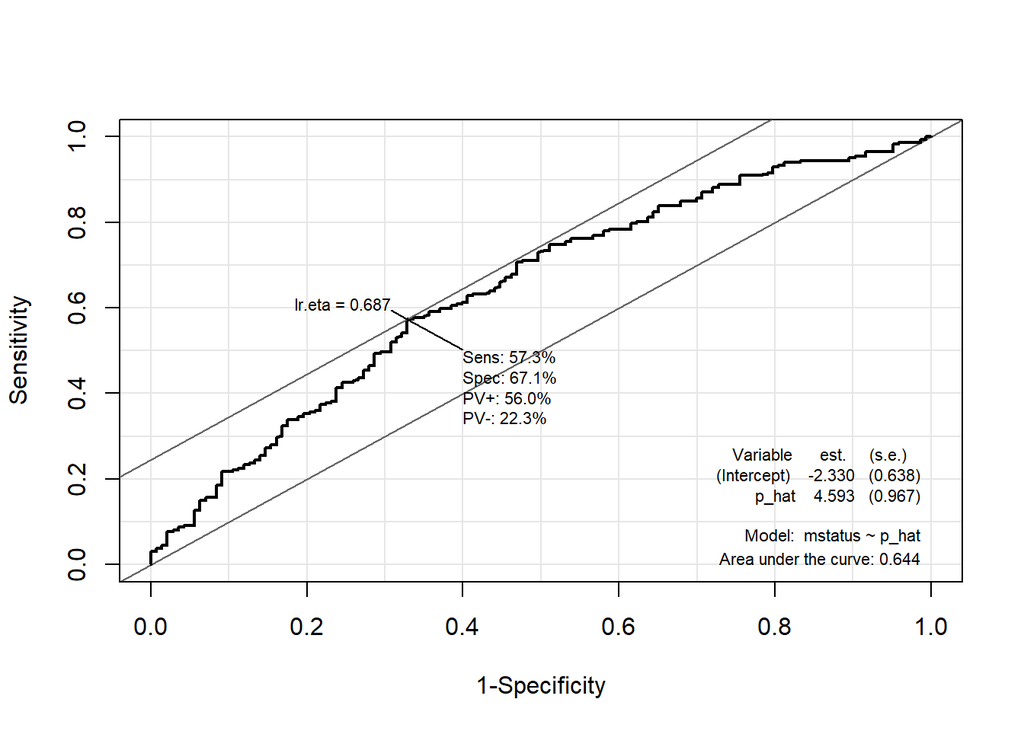

[output not shown]

[output cut: 375 more lines]

```

$AUC
[1] 0.6438946

$lr

Call:  glm(formula = form, family = binomial, data = data)

Coefficients:
(Intercept)        p_hat
     -2.330        4.593

Degrees of Freedom: 428 Total (i.e. Null);  427 Residual
Null Deviance:      546.1
Residual Deviance: 522.2    AIC: 526.2
```

## Confusion Matrix

```
          Truth
Prediction   0   1
         0  21  16
         1 122 270
```

## Assumptions Checks and Plots

```
    Hosmer and Lemeshow test (binary model)

data:  sdata$mstatus, fitted(logmodel1)
X-squared = 3.5346, df = 8, p-value = 0.8965
```

```
tlifesat  tposaff  tmarlow
1.219890 1.229505 1.010426
```

```
 tlifesat   tposaff   tmarlow
0.8197458 0.8133355 0.9896818
```

```
Call:
glm(formula = mstatus ~ tlifesat + tlifesat_log + tposaff + tposaff_log +
    tmarlow + tmarlow_log, family = binomial(link = "logit"),
    data = sdata)

Coefficients:
              Estimate Std. Error z value Pr(>|z|)
(Intercept)  -1.263618   2.690250  -0.470    0.639
tlifesat      0.102686   0.316014   0.325    0.745
tlifesat_log -0.008581   0.078883  -0.109    0.913
tposaff      -0.053617   0.382628  -0.140    0.889
tposaff_log   0.008804   0.086225   0.102    0.919
tmarlow       0.326028   0.559679   0.583    0.560
tmarlow_log  -0.072330   0.214166  -0.338    0.736

(Dispersion parameter for binomial family taken to be 1)

    Null deviance: 545.32  on 427  degrees of freedom
Residual deviance: 520.44  on 421  degrees of freedom
  (1 observation deleted due to missingness)
AIC: 534.44

Number of Fisher Scoring iterations: 4
```

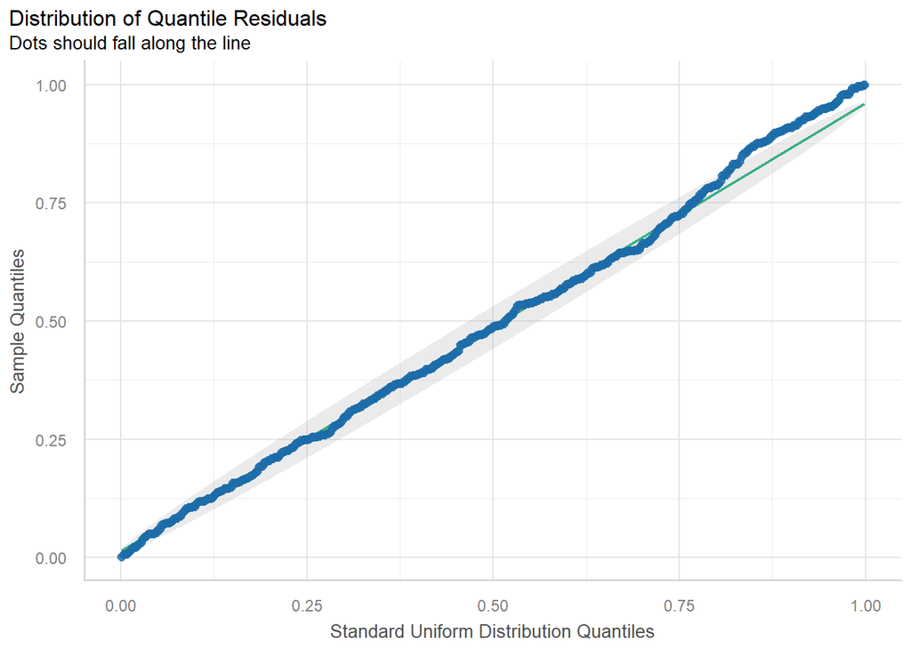

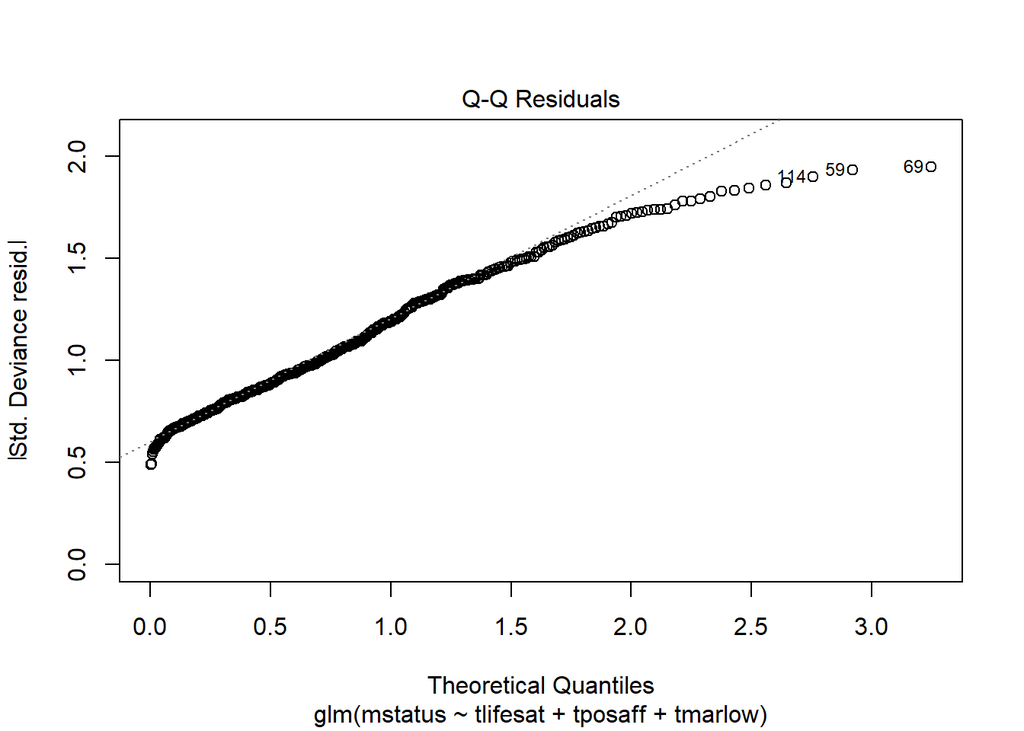

```
 42  59  69 114 115 134 157 217 364
 42  58  68 113 114 133 156 214 358
```

```
named integer(0)
```

```
      Min.    1st Qu.     Median       Mean    3rd Qu.       Max.
-2.3728341 -1.1192145  0.5520287  0.0000556  0.7263731  1.3354418
```

```
OK: Simulated residuals appear as uniformly distributed (p = 0.330).
```

```
        59        134        115         69          5        114         43
0.02012464 0.01460827 0.01289389 0.01183063 0.01103979 0.01077157 0.01075055
       364        241         20
0.01038150 0.01001943 0.00999167
```

```
named integer(0)
```

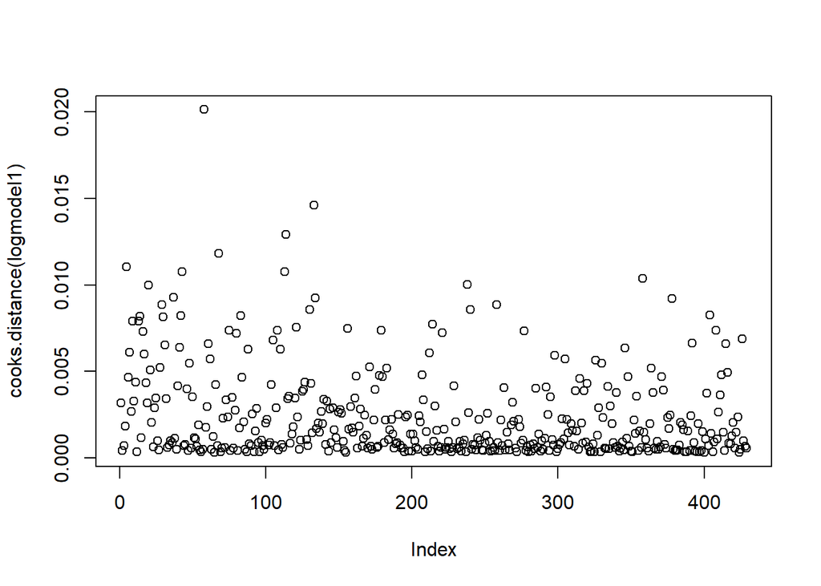

```
        30         41          6          7         13          9          8
0.04179350 0.03879557 0.03847979 0.03411562 0.03408393 0.03138220 0.02912687
       111          5         10
0.02885518 0.02659905 0.02433977
```

```
[1] 0.01864802
```

```
  3   5   6   7   8   9  10  13  14  21  30  32  38  40  41  43  60  62  75  81
  3   5   6   7   8   9  10  13  14  21  30  32  38  40  41  43  59  61  74  80
 89 111 210
 88 110 207
```

```
     row col
```

```
named integer(0)
```

```
      69       59      114      115      364      217      134      157
1.941419 1.920270 1.892579 1.859439 1.850597 1.837265 1.820958 1.820599
      42      135
1.796280 1.783256
```

# Appendix 3 - Comparison Model

## Model Fit

```
Call:
glm(formula = mstatus ~ tlifesat + tposaff + tmarlow + educ,
    family = binomial(link = "logit"), data = sdata)

Coefficients:
                             Estimate Std. Error z value Pr(>|z|)
(Intercept)                  -1.55811    0.61763  -2.523 0.011645 *
tlifesat                      0.07564    0.01835   4.123 3.74e-05 ***
tposaff                      -0.01290    0.01675  -0.770 0.441188
tmarlow                       0.10989    0.05398   2.036 0.041768 *
educCOMPLETED UNDERGRADUATE   0.07758    0.29691   0.261 0.793872
educPOSTGRADUATE COMPLETED    0.74942    0.37955   1.974 0.048328 *
educSOME ADDITIONAL TRAINING  0.64253    0.30921   2.078 0.037710 *
educSOME SECONDARY            1.97418    0.53284   3.705 0.000211 ***
---
Signif. codes:  0 '***' 0.001 '**' 0.01 '*' 0.05 '.' 0.1 ' ' 1

(Dispersion parameter for binomial family taken to be 1)

    Null deviance: 546.13  on 428  degrees of freedom
Residual deviance: 498.76  on 421  degrees of freedom
AIC: 514.76

Number of Fisher Scoring iterations: 4
```

```
Likelihood ratio test

Model 1: mstatus ~ tlifesat + tposaff + tmarlow + educ
Model 2: mstatus ~ 1
  #Df  LogLik Df  Chisq Pr(>Chisq)
1   8 -249.38
2   1 -273.06 -7 47.372  4.723e-08 ***
---
Signif. codes:  0 '***' 0.001 '**' 0.01 '*' 0.05 '.' 0.1 ' ' 1
```

```
CoxSnell
0.104546
```

```
Nagelkerke
 0.1451992
```

[output not shown]

## Odds Ratios

```
# A tibble: 8 × 7
  term                   estimate std.error statistic p.value conf.low conf.high
  <chr>                     <dbl>     <dbl>     <dbl>   <dbl>    <dbl>     <dbl>
1 (Intercept)               0.211    0.618     -2.52  1.16e-2   0.0618     0.700
2 tlifesat                  1.08     0.0183     4.12  3.74e-5   1.04       1.12
3 tposaff                   0.987    0.0167    -0.770 4.41e-1   0.955      1.02
4 tmarlow                   1.12     0.0540     2.04  4.18e-2   1.00       1.24
5 educCOMPLETED UNDERGR…    1.08     0.297      0.261 7.94e-1   0.602      1.93
6 educPOSTGRADUATE COMP…    2.12     0.380      1.97  4.83e-2   1.02       4.53
7 educSOME ADDITIONAL T…    1.90     0.309      2.08  3.77e-2   1.04       3.50
8 educSOME SECONDARY        7.20     0.533      3.71  2.11e-4   2.73      22.9
```

## Predicted Probabilities

```
 tlifesat tposaff tmarlow educ                      prob     SE  df asymp.LCL
     22.4    33.7    5.29 COMPLETED HIGHSCHOOL     0.570 0.0557 Inf     0.459
     22.4    33.7    5.29 COMPLETED UNDERGRADUATE  0.589 0.0464 Inf     0.496
     22.4    33.7    5.29 POSTGRADUATE COMPLETED   0.737 0.0592 Inf     0.606
     22.4    33.7    5.29 SOME ADDITIONAL TRAINING 0.716 0.0430 Inf     0.625
     22.4    33.7    5.29 SOME SECONDARY           0.905 0.0415 Inf     0.787
 asymp.UCL
     0.674
     0.676
     0.836
     0.792
     0.961

Confidence level used: 0.95
Intervals are back-transformed from the logit scale
```

## ROC Curve

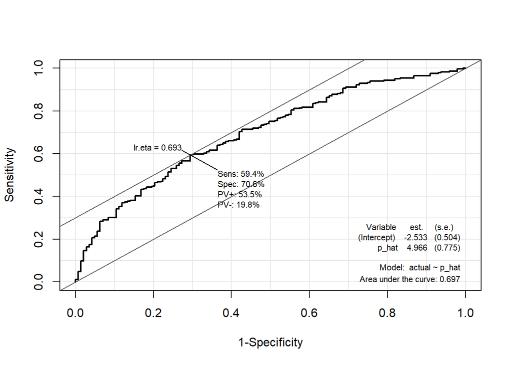

```
[1] 0.6971368
```

## Confusion Matrix

```
          Truth
Prediction   0   1
         0  41  25
         1 102 261
```

## Assumptions Checks

```
    Hosmer and Lemeshow test (binary model)

data:  sdata$mstatus, fitted(logmodel2)
X-squared = 2.4893, df = 8, p-value = 0.9622
```

```
             GVIF Df GVIF^(1/(2*Df))
tlifesat 1.274161  1        1.128788
tposaff  1.238577  1        1.112914
tmarlow  1.017555  1        1.008739
educ     1.054065  4        1.006603
```

```
              GVIF   Df GVIF^(1/(2*Df))
tlifesat 0.7848300 1.00       0.8859063
tposaff  0.8073781 1.00       0.8985422
tmarlow  0.9827476 1.00       0.9913363
educ     0.9487083 0.25       0.9934399
```

```
        59        131         24        292        301        109
0.04016570 0.03228270 0.02559560 0.02331416 0.02313831 0.01202046
```

```
named integer(0)
```

[figure not shown]

```
        43          6         14         30          9         67
0.06652612 0.05701222 0.05625865 0.05509010 0.05182989 0.04747849
```

```
[1] 0.03729604
```

```
  6   7   8   9  10  13  14  30  40  41  43  67  78  84 152 301
  6   7   8   9  10  13  14  30  40  41  43  66  77  83 151 295
```

```
     row col
```

```
 24  59 106 109 115 131 157 292 301 415
 24  58 105 108 114 130 156 287 295 408
```

```
      59      131       24      292      115      157
4.931218 3.854936 3.187181 2.606002 2.387618 2.292615
```

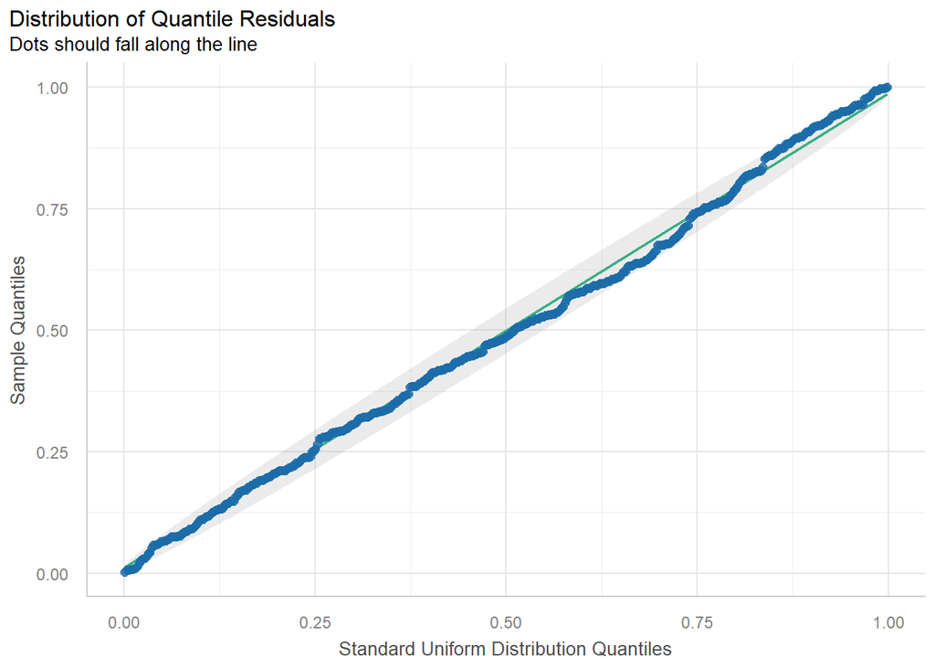

[figure not shown]

```
 24  59 131 292
 24  58 130 287
```